# Analysis 3: Upgraded Fulfillment-Time Proxy Model

This notebook upgrades the existing Analysis 3 model using a single interpretable `RidgeCV` specification on `log1p(hours_to_delivery)`.

The goal is not to build a production ETA engine. The goal is to build a more stable fulfillment-time proxy that can support relative candidate ranking in Part C.

```python
%matplotlib inline

from pathlib import Path

import numpy as np
import pandas as pd
import matplotlib.pyplot as plt

import inspect

from sklearn.compose import ColumnTransformer
from sklearn.impute import SimpleImputer
from sklearn.linear_model import RidgeCV
from sklearn.metrics import mean_absolute_error, mean_squared_error, r2_score
from sklearn.pipeline import Pipeline
from sklearn.preprocessing import OneHotEncoder, StandardScaler

pd.set_option("display.max_columns", 200)
pd.set_option("display.width", 180)

PROJECT_ROOT = Path.cwd().resolve().parent if Path.cwd().name == "notebooks" else Path.cwd()
ORDER_LINE_PATH = PROJECT_ROOT / "data" / "processed" / "order_line_with_inventory.csv"
CANDIDATE_PATH = PROJECT_ROOT / "data" / "processed" / "assignment_candidates.csv"

ORDER_LINE_PATH, CANDIDATE_PATH
```

```
(WindowsPath('E:/_NUS/Year2Sem2/IE5401/Project/Final Project/jd-fulfillment-optimization/data/processed/order_line_with_inventory.csv'),
 WindowsPath('E:/_NUS/Year2Sem2/IE5401/Project/Final Project/jd-fulfillment-optimization/data/processed/assignment_candidates.csv'))
```

## 1. Load the processed dataset defensively

```python
def pick_col(df: pd.DataFrame, *candidates: str, required: bool = True) -> str | None:
    for name in candidates:
        if name in df.columns:
            return name
    if required:
        raise KeyError(f"Missing required columns. Tried: {candidates}")
    return None


def stable_holdout_mask(series: pd.Series, train_share: float = 0.8) -> pd.Series:
    hashed = pd.util.hash_pandas_object(series.astype("string"), index=False).astype("uint64")
    return (hashed % 10) < int(train_share * 10)


raw_df = pd.read_csv(ORDER_LINE_PATH)
candidate_df = pd.read_csv(CANDIDATE_PATH) if CANDIDATE_PATH.exists() else None

colmap = {
    "order_line_id": pick_col(raw_df, "order_line_id"),
    "hours_to_delivery": pick_col(raw_df, "hours_to_delivery"),
    "delivered_by_jd_flag": pick_col(raw_df, "delivered_by_jd_flag", required=False),
    "remote_fulfillment_flag": pick_col(raw_df, "remote_fulfillment_flag"),
    "promise_days": pick_col(raw_df, "promise_days", "promise", required=False),
    "quantity": pick_col(raw_df, "quantity"),
    "discount_rate": pick_col(raw_df, "discount_rate"),
    "package_count": pick_col(raw_df, "package_count", required=False),
    "inventory_at_dc_des": pick_col(raw_df, "inventory_at_dc_des"),
    "inventory_at_dc_ori": pick_col(raw_df, "inventory_at_dc_ori"),
    "num_available_dcs_in_region": pick_col(raw_df, "num_available_dcs_in_region"),
    "sku_type_raw": pick_col(raw_df, "type_sku", "sku_type", "type", required=False),
    "plus": pick_col(raw_df, "plus", required=False),
    "user_level": pick_col(raw_df, "user_level", required=False),
    "purchase_power": pick_col(raw_df, "purchase_power", required=False),
    "city_level": pick_col(raw_df, "city_level", required=False),
    "destination_region_id": pick_col(raw_df, "destination_region_id", required=False),
}

print(f"order_line_with_inventory shape: {raw_df.shape}")
print(f"assignment_candidates shape: {candidate_df.shape if candidate_df is not None else 'not available'}")
print(sorted(raw_df.columns.tolist()))
```

[output not shown]

## 2. Build the modeling sample

Filtering rules:

- keep JD-logged rows if `delivered_by_jd_flag` exists,
- require non-missing `hours_to_delivery`,
- keep only positive hours,
- apply a light-touch outlier filter: `hours_to_delivery <= 240`.

```python
def build_modeling_sample(df: pd.DataFrame) -> pd.DataFrame:
    out = pd.DataFrame(
        {
            "order_line_id": df[colmap["order_line_id"]].astype("string"),
            "hours_to_delivery": pd.to_numeric(df[colmap["hours_to_delivery"]], errors="coerce"),
            "remote_fulfillment_flag": pd.to_numeric(df[colmap["remote_fulfillment_flag"]], errors="coerce"),
            "promise_days": pd.to_numeric(df[colmap["promise_days"]], errors="coerce") if colmap["promise_days"] else np.nan,
            "quantity": pd.to_numeric(df[colmap["quantity"]], errors="coerce"),
            "discount_rate": pd.to_numeric(df[colmap["discount_rate"]], errors="coerce"),
            "package_count": pd.to_numeric(df[colmap["package_count"]], errors="coerce") if colmap["package_count"] else np.nan,
            "inventory_at_fulfillment_dc": pd.to_numeric(df[colmap["inventory_at_dc_ori"]], errors="coerce"),
            "num_available_dcs_in_region": pd.to_numeric(df[colmap["num_available_dcs_in_region"]], errors="coerce"),
            "plus": pd.to_numeric(df[colmap["plus"]], errors="coerce") if colmap["plus"] else np.nan,
            "user_level": pd.to_numeric(df[colmap["user_level"]], errors="coerce") if colmap["user_level"] else np.nan,
            "purchase_power": pd.to_numeric(df[colmap["purchase_power"]], errors="coerce") if colmap["purchase_power"] else np.nan,
            "city_level": pd.to_numeric(df[colmap["city_level"]], errors="coerce") if colmap["city_level"] else np.nan,
            "destination_region_id": pd.to_numeric(df[colmap["destination_region_id"]], errors="coerce") if colmap["destination_region_id"] else np.nan,
        }
    )

    if colmap["delivered_by_jd_flag"]:
        out["delivered_by_jd_flag"] = pd.to_numeric(df[colmap["delivered_by_jd_flag"]], errors="coerce")
        out = out.loc[out["delivered_by_jd_flag"] == 1].copy()

    out = out.loc[out["hours_to_delivery"].notna()].copy()
    out = out.loc[out["hours_to_delivery"] > 0].copy()
    out = out.loc[out["hours_to_delivery"] <= 240].copy()

    sku_type_series = pd.to_numeric(df[colmap["sku_type_raw"]], errors="coerce") if colmap["sku_type_raw"] else pd.Series(np.nan, index=df.index)
    out["sku_type"] = np.select(
        [sku_type_series.loc[out.index].eq(1), sku_type_series.loc[out.index].eq(2)],
        ["1P", "3P"],
        default="Unknown",
    )

    out["promise_missing_flag"] = out["promise_days"].isna().astype(int)
    out["package_missing_flag"] = out["package_count"].isna().astype(int)
    out["region_missing_flag"] = out["destination_region_id"].isna().astype(int)
    out["log_hours_to_delivery"] = np.log1p(out["hours_to_delivery"])
    return out.reset_index(drop=True)


df_model = build_modeling_sample(raw_df)
train_mask = stable_holdout_mask(df_model["order_line_id"])

print(f"Raw processed rows: {len(raw_df):,}")
print(f"Modeling sample rows: {len(df_model):,}")
print(f"Train rows: {train_mask.sum():,}")
print(f"Test rows: {(~train_mask).sum():,}")

df_model[["hours_to_delivery", "log_hours_to_delivery"]].describe()
```

```
Raw processed rows: 549,989
Modeling sample rows: 326,238
Train rows: 261,231
Test rows: 65,007
```

|  | hours_to_delivery | log_hours_to_delivery |
| --- | --- | --- |
| count | 326238.000000 | 326238.000000 |
| mean | 34.142704 | 3.329984 |
| std | 27.012676 | 0.662620 |
| min | 0.486667 | 0.396536 |
| 25% | 17.501667 | 2.917861 |
| 50% | 23.833472 | 3.212192 |
| 75% | 44.135000 | 3.809658 |
| max | 239.848056 | 5.484166 |

## 3. Feature design

Core features:

- `remote_fulfillment_flag`
- `promise_days`
- `quantity`
- `discount_rate`
- `package_count`
- `inventory_at_fulfillment_dc`
- `num_available_dcs_in_region`
- `sku_type`
- `plus`
- `user_level`
- `purchase_power`
- `city_level`
- `destination_region_id`

Business-motivated interactions:

- `remote_x_inventory_at_fulfillment_dc`
- `remote_x_package_count`
- `remote_x_promise_days`
- `remote_x_sku_type_3p`

```python
def add_business_features(df: pd.DataFrame) -> pd.DataFrame:
    out = df.copy()
    out["sku_type_3p_flag"] = (out["sku_type"] == "3P").astype(float)
    out["remote_x_inventory_at_fulfillment_dc"] = out["remote_fulfillment_flag"] * out["inventory_at_fulfillment_dc"]
    out["remote_x_package_count"] = out["remote_fulfillment_flag"] * out["package_count"]
    out["remote_x_promise_days"] = out["remote_fulfillment_flag"] * out["promise_days"]
    out["remote_x_sku_type_3p"] = out["remote_fulfillment_flag"] * out["sku_type_3p_flag"]
    return out


df_model = add_business_features(df_model)

numeric_features = [
    "remote_fulfillment_flag",
    "promise_days",
    "promise_missing_flag",
    "quantity",
    "discount_rate",
    "package_count",
    "package_missing_flag",
    "inventory_at_fulfillment_dc",
    "num_available_dcs_in_region",
    "plus",
    "user_level",
    "purchase_power",
    "city_level",
    "remote_x_inventory_at_fulfillment_dc",
    "remote_x_package_count",
    "remote_x_promise_days",
    "remote_x_sku_type_3p",
]

categorical_features = [
    "sku_type",
    "destination_region_id",
]

feature_columns = numeric_features + categorical_features

X_train_raw = df_model.loc[train_mask, feature_columns].copy()
X_test_raw = df_model.loc[~train_mask, feature_columns].copy()
y_train_log = df_model.loc[train_mask, "log_hours_to_delivery"].copy()
y_test_hours = df_model.loc[~train_mask, "hours_to_delivery"].copy()

X_train_raw.head()
```

|  | remote_fulfillment_flag | promise_days | promise_missing_flag | quantity | discount_rate | package_count | package_missing_flag | inventory_at_fulfillment_dc | num_available_dcs_in_region | plus | user_level | purchase_power | city_level | remote_x_inventory_at_fulfillment_dc | remote_x_package_count | remote_x_promise_days | remote_x_sku_type_3p | sku_type | destination_region_id |
| --- | --- | --- | --- | --- | --- | --- | --- | --- | --- | --- | --- | --- | --- | --- | --- | --- | --- | --- | --- |
| 0 | 0 | 2.0 | 0 | 1 | 0.460460 | 1.0 | 0 | 0 | 6 | 0 | 1 | 3 | 2 | 0 | 0.0 | 0.0 | 0.0 | 1P | 4.0 |
| 2 | 1 | 2.0 | 0 | 1 | 0.426230 | 1.0 | 0 | 1 | 7 | 0 | 3 | 2 | 2 | 1 | 1.0 | 2.0 | 0.0 | Unknown | 4.0 |
| 3 | 1 | 1.0 | 0 | 1 | 0.320513 | 1.0 | 0 | 1 | 0 | 0 | 1 | 4 | 2 | 1 | 1.0 | 1.0 | 0.0 | Unknown | NaN |
| 4 | 1 | 1.0 | 0 | 1 | 0.513141 | 1.0 | 0 | 1 | 0 | 0 | 2 | 2 | 2 | 1 | 1.0 | 1.0 | 0.0 | 1P | NaN |
| 5 | 1 | 1.0 | 0 | 1 | NaN | 1.0 | 0 | 1 | 0 | 0 | 2 | -1 | 2 | 1 | 1.0 | 1.0 | 0.0 | 1P | NaN |

## 4. Preprocessing pipeline

Preprocessing choices:

- median imputation for numeric predictors,
- most-frequent imputation for categorical predictors,
- standardization for numeric predictors,
- one-hot encoding for `sku_type` and `destination_region_id`,
- IDs are excluded from the model.

```python
def make_onehot_encoder():
    params = inspect.signature(OneHotEncoder).parameters
    if "sparse_output" in params:
        return OneHotEncoder(handle_unknown="ignore", sparse_output=False)
    if "sparse" in params:
        return OneHotEncoder(handle_unknown="ignore", sparse=False)
    return OneHotEncoder(handle_unknown="ignore")


numeric_transformer = Pipeline(
    steps=[
        ("imputer", SimpleImputer(strategy="median")),
        ("scaler", StandardScaler()),
    ]
)

categorical_transformer = Pipeline(
    steps=[
        ("imputer", SimpleImputer(strategy="most_frequent")),
        ("onehot", make_onehot_encoder()),
    ]
)

preprocessor = ColumnTransformer(
    transformers=[
        ("num", numeric_transformer, numeric_features),
        ("cat", categorical_transformer, categorical_features),
    ]
)

alphas = np.array([0.01, 0.1, 1.0, 3.0, 10.0, 30.0, 100.0])

ridge_pipeline = Pipeline(
    steps=[
        ("preprocessor", preprocessor),
        ("ridge", RidgeCV(alphas=alphas, cv=5)),
    ]
)
```

## 5. Main model code

```python
ridge_pipeline.fit(X_train_raw, y_train_log)

pred_test_log = ridge_pipeline.predict(X_test_raw)
pred_test_hours = np.expm1(pred_test_log)
pred_test_hours = np.clip(pred_test_hours, a_min=0, a_max=None)

selected_alpha = ridge_pipeline.named_steps["ridge"].alpha_
selected_alpha
```

```
np.float64(100.0)
```

## 6. Evaluation results

Evaluation is reported on the original hours scale, not the log scale.

```python
rmse = float(np.sqrt(mean_squared_error(y_test_hours, pred_test_hours)))
mae = mean_absolute_error(y_test_hours, pred_test_hours)
r2 = r2_score(y_test_hours, pred_test_hours)

evaluation_table = pd.DataFrame(
    {
        "metric": ["RMSE", "MAE", "R2", "Selected alpha"],
        "value": [rmse, mae, r2, selected_alpha],
    }
)
evaluation_table
```

|  | metric | value |
| --- | --- | --- |
| 0 | RMSE | 20.053595 |
| 1 | MAE | 11.314186 |
| 2 | R2 | 0.438062 |
| 3 | Selected alpha | 100.000000 |

## 7. Coefficient interpretation

The coefficient table below is shown on the standardized feature scale used by the fitted Ridge model. Coefficients should be interpreted directionally and comparatively, not causally.

```python
feature_names = ridge_pipeline.named_steps["preprocessor"].get_feature_names_out()
ridge_coef = ridge_pipeline.named_steps["ridge"].coef_

coef_table = pd.DataFrame(
    {
        "feature": feature_names,
        "coefficient": ridge_coef,
        "abs_coefficient": np.abs(ridge_coef),
    }
).sort_values("abs_coefficient", ascending=False).reset_index(drop=True)

coef_table.head(25)
```

|  | feature | coefficient | abs_coefficient |
| --- | --- | --- | --- |
| 0 | num__promise_days | 0.413887 | 0.413887 |
| 1 | cat__destination_region_id_2.0 | -0.084046 | 0.084046 |
| 2 | cat__destination_region_id_4.0 | 0.078168 | 0.078168 |
| 3 | cat__destination_region_id_10.0 | -0.076607 | 0.076607 |
| 4 | num__remote_x_promise_days | -0.067637 | 0.067637 |
| 5 | cat__destination_region_id_9.0 | 0.066438 | 0.066438 |
| 6 | num__inventory_at_fulfillment_dc | -0.046823 | 0.046823 |
| 7 | num__discount_rate | 0.046308 | 0.046308 |
| 8 | num__promise_missing_flag | 0.041345 | 0.041345 |
| 9 | cat__destination_region_id_24.0 | 0.040809 | 0.040809 |
| 10 | num__remote_x_package_count | 0.038577 | 0.038577 |
| 11 | cat__sku_type_1P | -0.037814 | 0.037814 |
| 12 | cat__sku_type_3P | 0.034578 | 0.034578 |
| 13 | num__remote_fulfillment_flag | 0.034490 | 0.034490 |
| 14 | cat__destination_region_id_5.0 | -0.033948 | 0.033948 |
| 15 | num__num_available_dcs_in_region | -0.028683 | 0.028683 |
| 16 | num__remote_x_inventory_at_fulfillment_dc | 0.019601 | 0.019601 |
| 17 | cat__destination_region_id_7.0 | 0.013865 | 0.013865 |
| 18 | num__purchase_power | -0.013237 | 0.013237 |
| 19 | num__remote_x_sku_type_3p | 0.010303 | 0.010303 |
| 20 | num__plus | -0.006951 | 0.006951 |
| 21 | num__quantity | 0.006527 | 0.006527 |
| 22 | num__user_level | 0.006217 | 0.006217 |
| 23 | num__package_count | 0.006113 | 0.006113 |
| 24 | num__city_level | 0.005378 | 0.005378 |

```python
focus_patterns = [
    "remote_fulfillment_flag",
    "inventory_at_fulfillment_dc",
    "num_available_dcs_in_region",
    "package_count",
    "promise_days",
    "remote_x_",
    "sku_type",
]

coef_focus = coef_table.loc[
    coef_table["feature"].apply(lambda x: any(pattern in x for pattern in focus_patterns))
].reset_index(drop=True)
coef_focus.head(30)
```

|  | feature | coefficient | abs_coefficient |
| --- | --- | --- | --- |
| 0 | num__promise_days | 0.413887 | 0.413887 |
| 1 | num__remote_x_promise_days | -0.067637 | 0.067637 |
| 2 | num__inventory_at_fulfillment_dc | -0.046823 | 0.046823 |
| 3 | num__remote_x_package_count | 0.038577 | 0.038577 |
| 4 | cat__sku_type_1P | -0.037814 | 0.037814 |
| 5 | cat__sku_type_3P | 0.034578 | 0.034578 |
| 6 | num__remote_fulfillment_flag | 0.034490 | 0.034490 |
| 7 | num__num_available_dcs_in_region | -0.028683 | 0.028683 |
| 8 | num__remote_x_inventory_at_fulfillment_dc | 0.019601 | 0.019601 |
| 9 | num__remote_x_sku_type_3p | 0.010303 | 0.010303 |
| 10 | num__package_count | 0.006113 | 0.006113 |
| 11 | cat__sku_type_Unknown | 0.003236 | 0.003236 |

## 8. Light diagnostics

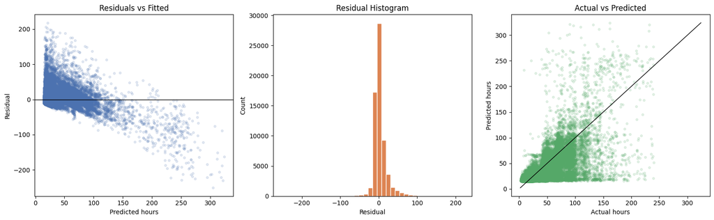

```python
residuals_hours = y_test_hours - pred_test_hours

fig, axes = plt.subplots(1, 3, figsize=(16, 5))

axes[0].scatter(pred_test_hours, residuals_hours, alpha=0.15, s=12, color="#4C72B0")
axes[0].axhline(0, color="black", linewidth=1)
axes[0].set_title("Residuals vs Fitted")
axes[0].set_xlabel("Predicted hours")
axes[0].set_ylabel("Residual")

axes[1].hist(residuals_hours, bins=40, color="#DD8452", edgecolor="white")
axes[1].set_title("Residual Histogram")
axes[1].set_xlabel("Residual")
axes[1].set_ylabel("Count")

axes[2].scatter(y_test_hours, pred_test_hours, alpha=0.15, s=12, color="#55A868")
diag_min = min(y_test_hours.min(), pred_test_hours.min())
diag_max = max(y_test_hours.max(), pred_test_hours.max())
axes[2].plot([diag_min, diag_max], [diag_min, diag_max], color="black", linewidth=1)
axes[2].set_title("Actual vs Predicted")
axes[2].set_xlabel("Actual hours")
axes[2].set_ylabel("Predicted hours")

plt.tight_layout()
plt.show()
```

## 9. Candidate scoring redesign for Part C

Important distinction:

- training uses realized historical fulfillment outcomes,
- candidate scoring must rebuild the same feature concepts for each hypothetical `candidate_dc`.

In particular:

- do not reuse realized `dc_ori`-dependent fields directly,
- do use candidate-specific remote and inventory variables.

```python
candidate_mapping = pd.DataFrame(
    [
        {
            "concept": "remote_fulfillment_flag",
            "historical_training_version": "observed remote_fulfillment_flag",
            "candidate_scoring_version": "candidate_remote_flag or 1(candidate_dc != dc_des)",
        },
        {
            "concept": "inventory_at_fulfillment_dc",
            "historical_training_version": "inventory_at_dc_ori for the actual fulfillment warehouse",
            "candidate_scoring_version": "inventory_available for (order_date, sku_id, candidate_dc)",
        },
        {
            "concept": "num_available_dcs_in_region",
            "historical_training_version": "num_available_dcs_in_region",
            "candidate_scoring_version": "same region-level stock flexibility merged from order-line data",
        },
    ]
)
candidate_mapping
```

|  | concept | historical_training_version | candidate_scoring_version |
| --- | --- | --- | --- |
| 0 | remote_fulfillment_flag | observed remote_fulfillment_flag | candidate_remote_flag or 1(candidate_dc != dc_... |
| 1 | inventory_at_fulfillment_dc | inventory_at_dc_ori for the actual fulfillment... | inventory_available for (order_date, sku_id, c... |
| 2 | num_available_dcs_in_region | num_available_dcs_in_region | same region-level stock flexibility merged fro... |

```python
def build_candidate_feature_frame(candidate_rows: pd.DataFrame, order_line_df: pd.DataFrame) -> pd.DataFrame:
    static_cols = [
        "order_line_id",
        "quantity",
        "discount_rate",
        "promise_days",
        "plus",
        "user_level",
        "purchase_power",
        "city_level",
        "destination_region_id",
        "num_available_dcs_in_region",
        "package_count",
        "sku_type",
    ]
    available_static_cols = [col for col in static_cols if col in order_line_df.columns]
    static_lookup = order_line_df[available_static_cols].drop_duplicates(subset=["order_line_id"]).copy()
    work = candidate_rows.copy().merge(static_lookup, how="left", on="order_line_id", validate="m:1", suffixes=("", "_hist"))

    if "destination_region_id" not in work.columns:
        if "destination_region_id_hist" in work.columns:
            work["destination_region_id"] = work["destination_region_id_hist"]
        elif "destination_region_id" in candidate_rows.columns:
            work["destination_region_id"] = candidate_rows["destination_region_id"]
        else:
            work["destination_region_id"] = np.nan
    elif work["destination_region_id"].isna().all() and "destination_region_id_hist" in work.columns:
        work["destination_region_id"] = work["destination_region_id"].fillna(work["destination_region_id_hist"])

    work["remote_fulfillment_flag"] = pd.to_numeric(work["candidate_remote_flag"], errors="coerce")
    work["inventory_at_fulfillment_dc"] = pd.to_numeric(work["inventory_available"], errors="coerce")
    work["promise_missing_flag"] = pd.to_numeric(work["promise_days"], errors="coerce").isna().astype(int)
    work["package_missing_flag"] = pd.to_numeric(work["package_count"], errors="coerce").isna().astype(int)
    return add_business_features(work)


def score_assignment_candidates(
    candidate_rows: pd.DataFrame,
    order_line_df: pd.DataFrame,
    fitted_pipeline: Pipeline,
    package_count_assumption: str = "median",
) -> pd.DataFrame:
    work = build_candidate_feature_frame(candidate_rows=candidate_rows, order_line_df=order_line_df)

    if package_count_assumption == "median":
        work["package_count"] = work["package_count"].fillna(order_line_df["package_count"].median())
    elif package_count_assumption == "one":
        work["package_count"] = work["package_count"].fillna(1.0)
    else:
        raise ValueError("package_count_assumption must be 'median' or 'one'.")

    model_input = work[feature_columns].copy()
    pred_log = fitted_pipeline.predict(model_input)
    work["predicted_hours_to_delivery"] = np.clip(np.expm1(pred_log), a_min=0, a_max=None)
    return work


if candidate_df is not None:
    scored_candidates = score_assignment_candidates(
        candidate_rows=candidate_df.head(1000).copy(),
        order_line_df=df_model,
        fitted_pipeline=ridge_pipeline,
        package_count_assumption="median",
    )
    scored_candidates[
        [
            "order_line_id",
            "candidate_dc",
            "candidate_remote_flag",
            "inventory_available",
            "predicted_hours_to_delivery",
        ]
    ].head(10)
else:
    print("assignment_candidates.csv not available")
```

```python
from pathlib import Path
import matplotlib.pyplot as plt
from matplotlib.patches import Rectangle, FancyArrowPatch
import pandas as pd
import numpy as np

PROJECT_ROOT = Path.cwd().resolve().parent if Path.cwd().name == "notebooks" else Path.cwd()
GRAPH_DIR = PROJECT_ROOT / "data" / "processed" / "report_graphs"
GRAPH_DIR.mkdir(parents=True, exist_ok=True)

def save_fig(name):
    path = GRAPH_DIR / name
    plt.savefig(path, dpi=300, bbox_inches="tight")
    plt.close()
    print(f"Saved: {path}")

def arrow(ax, start, end):
    ax.add_patch(FancyArrowPatch(start, end, arrowstyle="->", mutation_scale=14, linewidth=1.5))

# Graph 3.7: Predictive Model Framework
fig, ax = plt.subplots(figsize=(11, 4))
ax.axis("off")

boxes = {
    "Input Features\nquantity, discount,\nseller type, inventory,\ncross-DC, promise": (0.05, 0.42),
    "Predictive\nModel": (0.42, 0.42),
    "Output\nDelivery Time /\nLate Risk": (0.74, 0.42)
}

for label, (x, y) in boxes.items():
    ax.add_patch(Rectangle((x, y), 0.22, 0.24, fill=False, linewidth=1.8))
    ax.text(x + 0.11, y + 0.12, label, ha="center", va="center", fontsize=10)

arrow(ax, (0.27, 0.54), (0.42, 0.54))
arrow(ax, (0.64, 0.54), (0.74, 0.54))

ax.set_title("Predictive Model Framework for Fulfillment Performance", fontsize=14, weight="bold")
save_fig("chapter3_graph7_predictive_model_framework.png")


# Graph 3.8: Actual vs Predicted Delivery Time
actual_candidates = ["y_test", "y_true", "actual", "actual_values"]
pred_candidates = ["y_pred", "predictions", "y_hat", "predicted_values"]

actual = None
pred = None

for c in actual_candidates:
    if c in globals():
        actual = globals()[c]
        print(f"Using actual variable: {c}")
        break

for c in pred_candidates:
    if c in globals():
        pred = globals()[c]
        print(f"Using prediction variable: {c}")
        break

if actual is not None and pred is not None:
    actual = np.array(actual).flatten()
    pred = np.array(pred).flatten()

    sample_size = min(len(actual), len(pred), 3000)
    idx = np.random.choice(len(actual), sample_size, replace=False) if len(actual) > sample_size else np.arange(len(actual))

    plt.figure(figsize=(6, 6))
    plt.scatter(actual[idx], pred[idx], alpha=0.35)
    min_val = min(actual[idx].min(), pred[idx].min())
    max_val = max(actual[idx].max(), pred[idx].max())
    plt.plot([min_val, max_val], [min_val, max_val], linestyle="--")
    plt.xlabel("Actual Delivery Time")
    plt.ylabel("Predicted Delivery Time")
    plt.title("Actual vs Predicted Delivery Time")
    save_fig("chapter3_graph8_actual_vs_predicted_delivery.png")
else:
    print("Skipped actual vs predicted graph: y_test/y_true and y_pred were not found.")
```

```
Saved: E:\_NUS\Year2Sem2\IE5401\Project\Final Project\jd-fulfillment-optimization\data\processed\report_graphs\chapter3_graph7_predictive_model_framework.png
Using actual variable: actual
Skipped actual vs predicted graph: y_test/y_true and y_pred were not found.
```

```python
from pathlib import Path
import matplotlib.pyplot as plt
import numpy as np
import pandas as pd

PROJECT_ROOT = Path.cwd().resolve().parent if Path.cwd().name == "notebooks" else Path.cwd()
GRAPH_DIR = PROJECT_ROOT / "data" / "processed" / "report_graphs"
GRAPH_DIR.mkdir(parents=True, exist_ok=True)

def save_fig(name):
    path = GRAPH_DIR / name
    plt.savefig(path, dpi=300, bbox_inches="tight")
    plt.close()
    print(f"Saved: {path}")

# ------------------------------------------------------------
# Detect ACTUAL values
# ------------------------------------------------------------

actual_candidates = [
    "actual", "y_test", "y_true", "actual_values", "test_actual"
]

pred_candidates = [
    "pred", "prediction", "predictions", "y_pred",
    "forecast", "test_pred", "predicted"
]

actual = None
pred = None

for var in actual_candidates:
    if var in globals():
        actual = globals()[var]
        print("Using actual variable:", var)
        break

for var in pred_candidates:
    if var in globals():
        pred = globals()[var]
        print("Using prediction variable:", var)
        break

# ------------------------------------------------------------
# Plot
# ------------------------------------------------------------

if actual is not None and pred is not None:

    actual = np.array(actual).flatten()
    pred = np.array(pred).flatten()

    n = min(len(actual), len(pred))
    actual = actual[:n]
    pred = pred[:n]

    sample_size = min(n, 3000)

    if n > sample_size:
        idx = np.random.choice(n, sample_size, replace=False)
        actual_plot = actual[idx]
        pred_plot = pred[idx]
    else:
        actual_plot = actual
        pred_plot = pred

    plt.figure(figsize=(6,6))
    plt.scatter(actual_plot, pred_plot, alpha=0.35)

    min_val = min(actual_plot.min(), pred_plot.min())
    max_val = max(actual_plot.max(), pred_plot.max())

    plt.plot(
        [min_val, max_val],
        [min_val, max_val],
        linestyle="--",
        linewidth=1.5
    )

    plt.xlabel("Actual Delivery Time")
    plt.ylabel("Predicted Delivery Time")
    plt.title("Actual vs Predicted Delivery Time")
    plt.tight_layout()

    save_fig("chapter3_graph8_actual_vs_predicted_delivery.png")

else:
    print("Prediction variable still not found.")
    print("Run this command to inspect:")
    print(globals().keys())
```

[output not shown]

```python
from pathlib import Path
import matplotlib.pyplot as plt
import numpy as np

PROJECT_ROOT = Path.cwd().resolve().parent if Path.cwd().name == "notebooks" else Path.cwd()
GRAPH_DIR = PROJECT_ROOT / "data" / "processed" / "report_graphs"
GRAPH_DIR.mkdir(parents=True, exist_ok=True)

def save_fig(name):
    path = GRAPH_DIR / name
    plt.savefig(path, dpi=300, bbox_inches="tight")
    plt.close()
    print(f"Saved: {path}")

actual = np.array(y_test_hours).flatten()
predicted = np.array(pred_test_hours).flatten()

n = min(len(actual), len(predicted))
actual = actual[:n]
predicted = predicted[:n]

sample_size = min(n, 3000)

if n > sample_size:
    idx = np.random.choice(n, sample_size, replace=False)
    actual_plot = actual[idx]
    predicted_plot = predicted[idx]
else:
    actual_plot = actual
    predicted_plot = predicted

plt.figure(figsize=(6, 6))
plt.scatter(actual_plot, predicted_plot, alpha=0.35)

min_val = min(actual_plot.min(), predicted_plot.min())
max_val = max(actual_plot.max(), predicted_plot.max())

plt.plot(
    [min_val, max_val],
    [min_val, max_val],
    linestyle="--",
    linewidth=1.5
)

plt.xlabel("Actual Delivery Time (hours)")
plt.ylabel("Predicted Delivery Time (hours)")
plt.title("Actual vs Predicted Delivery Time")
plt.tight_layout()

save_fig("chapter3_graph8_actual_vs_predicted_delivery.png")
```

```
Saved: E:\_NUS\Year2Sem2\IE5401\Project\Final Project\jd-fulfillment-optimization\data\processed\report_graphs\chapter3_graph8_actual_vs_predicted_delivery.png
```

|  | metric | value |
| --- | --- | --- |
| 0 | RMSE | 20.053595 |
| 1 | MAE | 11.314186 |
| 2 | R2 | 0.438062 |
| 3 | Selected alpha | 100.000000 |

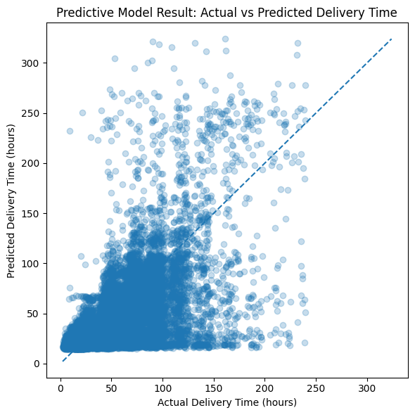

```
Saved: E:\_NUS\Year2Sem2\IE5401\Project\Final Project\jd-fulfillment-optimization\data\processed\report_graphs\chapter4_graph5_actual_vs_predicted_delivery.png
```

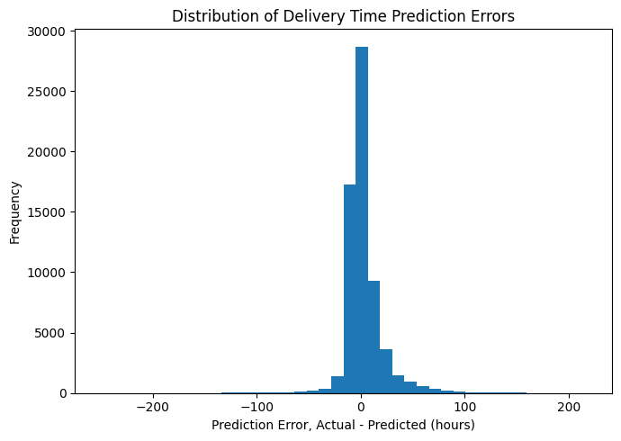

```
Saved: E:\_NUS\Year2Sem2\IE5401\Project\Final Project\jd-fulfillment-optimization\data\processed\report_graphs\chapter4_graph6_prediction_error_distribution.png
```

|  | feature | coefficient | abs_coefficient |
| --- | --- | --- | --- |
| 0 | num__promise_days | 0.413887 | 0.413887 |
| 1 | cat__destination_region_id_2.0 | -0.084046 | 0.084046 |
| 2 | cat__destination_region_id_4.0 | 0.078168 | 0.078168 |
| 3 | cat__destination_region_id_10.0 | -0.076607 | 0.076607 |
| 4 | num__remote_x_promise_days | -0.067637 | 0.067637 |
| 5 | cat__destination_region_id_9.0 | 0.066438 | 0.066438 |
| 6 | num__inventory_at_fulfillment_dc | -0.046823 | 0.046823 |
| 7 | num__discount_rate | 0.046308 | 0.046308 |
| 8 | num__promise_missing_flag | 0.041345 | 0.041345 |
| 9 | cat__destination_region_id_24.0 | 0.040809 | 0.040809 |
| 10 | num__remote_x_package_count | 0.038577 | 0.038577 |
| 11 | cat__sku_type_1P | -0.037814 | 0.037814 |
| 12 | cat__sku_type_3P | 0.034578 | 0.034578 |
| 13 | num__remote_fulfillment_flag | 0.034490 | 0.034490 |
| 14 | cat__destination_region_id_5.0 | -0.033948 | 0.033948 |
| 15 | num__num_available_dcs_in_region | -0.028683 | 0.028683 |
| 16 | num__remote_x_inventory_at_fulfillment_dc | 0.019601 | 0.019601 |
| 17 | cat__destination_region_id_7.0 | 0.013865 | 0.013865 |
| 18 | num__purchase_power | -0.013237 | 0.013237 |
| 19 | num__remote_x_sku_type_3p | 0.010303 | 0.010303 |

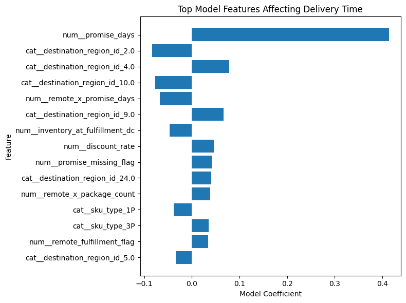

```
Saved: E:\_NUS\Year2Sem2\IE5401\Project\Final Project\jd-fulfillment-optimization\data\processed\report_graphs\chapter4_graph7_top_model_coefficients.png
```

```python
from pathlib import Path
import pandas as pd
import numpy as np
import matplotlib.pyplot as plt

PROJECT_ROOT = Path.cwd().resolve().parent if Path.cwd().name == "notebooks" else Path.cwd()
RESULT_DIR = PROJECT_ROOT / "data" / "processed" / "chapter4_results"
GRAPH_DIR = PROJECT_ROOT / "data" / "processed" / "report_graphs"

RESULT_DIR.mkdir(parents=True, exist_ok=True)
GRAPH_DIR.mkdir(parents=True, exist_ok=True)

def save_fig(name):
    path = GRAPH_DIR / name
    plt.savefig(path, dpi=300, bbox_inches="tight")
    plt.close()
    print(f"Saved: {path}")

# Save model evaluation table
if "evaluation_table" in globals():
    evaluation_table.to_csv(RESULT_DIR / "chapter4_model_evaluation_table.csv", index=False)
    display(evaluation_table)
else:
    print("evaluation_table not found.")

# Actual vs predicted plot
actual = np.array(y_test_hours).flatten()
predicted = np.array(pred_test_hours).flatten()

n = min(len(actual), len(predicted))
actual = actual[:n]
predicted = predicted[:n]

plt.figure(figsize=(6,6))
plt.scatter(actual, predicted, alpha=0.25)

min_val = min(actual.min(), predicted.min())
max_val = max(actual.max(), predicted.max())

plt.plot([min_val, max_val], [min_val, max_val], linestyle="--")

plt.xlabel("Actual Delivery Time (hours)")
plt.ylabel("Predicted Delivery Time (hours)")
plt.title("Predictive Model Result: Actual vs Predicted Delivery Time")
plt.tight_layout()
plt.show()
save_fig("chapter4_graph5_actual_vs_predicted_delivery.png")

# Residual distribution
residuals = actual - predicted

plt.figure(figsize=(7,5))
plt.hist(residuals, bins=40)
plt.xlabel("Prediction Error, Actual - Predicted (hours)")
plt.ylabel("Frequency")
plt.title("Distribution of Delivery Time Prediction Errors")
plt.tight_layout()
plt.show()
save_fig("chapter4_graph6_prediction_error_distribution.png")

# Top coefficients if available
if "coef_table" in globals():
    coef_table.to_csv(RESULT_DIR / "chapter4_model_coefficients.csv", index=False)
    display(coef_table.head(20))

    top_coef = coef_table.copy()
    coef_col = [c for c in top_coef.columns if "coef" in c.lower()][0]
    feature_col = [c for c in top_coef.columns if "feature" in c.lower()][0]

    top_coef["abs_coef"] = top_coef[coef_col].abs()
    top_coef = top_coef.sort_values("abs_coef", ascending=False).head(15)

    plt.figure(figsize=(8,6))
    plt.barh(top_coef[feature_col], top_coef[coef_col])
    plt.xlabel("Model Coefficient")
    plt.ylabel("Feature")
    plt.title("Top Model Features Affecting Delivery Time")
    plt.gca().invert_yaxis()
    plt.tight_layout()
    plt.show()
    save_fig("chapter4_graph7_top_model_coefficients.png")
```

```
Model Evaluation Table:
```

|  | metric | value |
| --- | --- | --- |
| 0 | RMSE | 20.053595 |
| 1 | MAE | 11.314186 |
| 2 | R2 | 0.438062 |
| 3 | Selected alpha | 100.000000 |

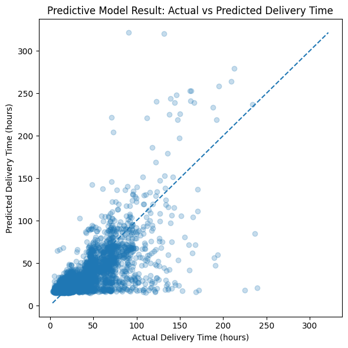

```
Saved: E:\_NUS\Year2Sem2\IE5401\Project\Final Project\jd-fulfillment-optimization\data\processed\report_graphs\chapter4_graph5_actual_vs_predicted_delivery.png

Prediction Error Summary:
```

|  | Metric | Value |
| --- | --- | --- |
| 0 | Mean Error | 2.780259 |
| 1 | Median Error | -0.060734 |
| 2 | Std Error | 19.859930 |
| 3 | Min Error | -251.453421 |
| 4 | Max Error | 218.196082 |

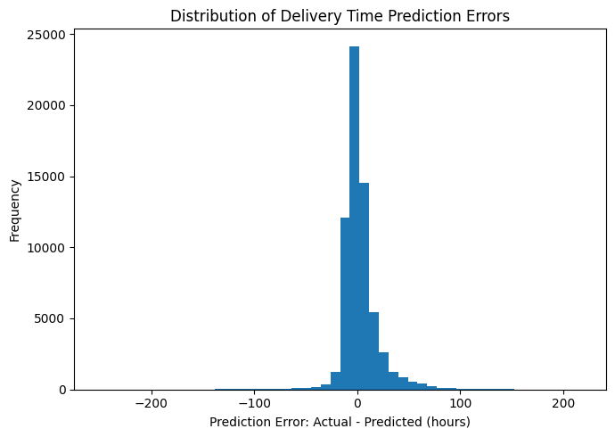

```
Saved: E:\_NUS\Year2Sem2\IE5401\Project\Final Project\jd-fulfillment-optimization\data\processed\report_graphs\chapter4_graph6_prediction_error_distribution.png

Top Model Coefficients:
```

|  | feature | coefficient | abs_coefficient |
| --- | --- | --- | --- |
| 0 | num__promise_days | 0.413887 | 0.413887 |
| 1 | cat__destination_region_id_2.0 | -0.084046 | 0.084046 |
| 2 | cat__destination_region_id_4.0 | 0.078168 | 0.078168 |
| 3 | cat__destination_region_id_10.0 | -0.076607 | 0.076607 |
| 4 | num__remote_x_promise_days | -0.067637 | 0.067637 |
| 5 | cat__destination_region_id_9.0 | 0.066438 | 0.066438 |
| 6 | num__inventory_at_fulfillment_dc | -0.046823 | 0.046823 |
| 7 | num__discount_rate | 0.046308 | 0.046308 |
| 8 | num__promise_missing_flag | 0.041345 | 0.041345 |
| 9 | cat__destination_region_id_24.0 | 0.040809 | 0.040809 |
| 10 | num__remote_x_package_count | 0.038577 | 0.038577 |
| 11 | cat__sku_type_1P | -0.037814 | 0.037814 |
| 12 | cat__sku_type_3P | 0.034578 | 0.034578 |
| 13 | num__remote_fulfillment_flag | 0.034490 | 0.034490 |
| 14 | cat__destination_region_id_5.0 | -0.033948 | 0.033948 |
| 15 | num__num_available_dcs_in_region | -0.028683 | 0.028683 |
| 16 | num__remote_x_inventory_at_fulfillment_dc | 0.019601 | 0.019601 |
| 17 | cat__destination_region_id_7.0 | 0.013865 | 0.013865 |
| 18 | num__purchase_power | -0.013237 | 0.013237 |
| 19 | num__remote_x_sku_type_3p | 0.010303 | 0.010303 |

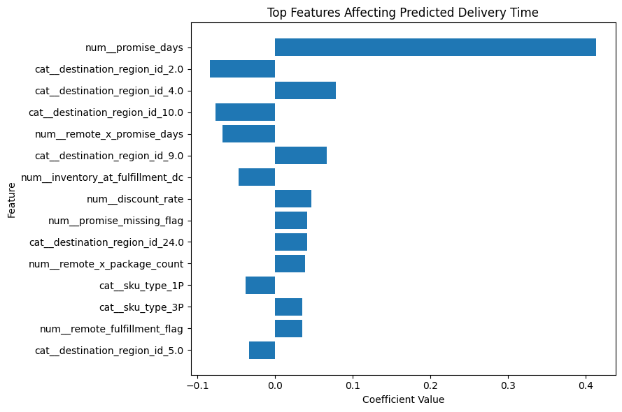

```
Saved: E:\_NUS\Year2Sem2\IE5401\Project\Final Project\jd-fulfillment-optimization\data\processed\report_graphs\chapter4_graph7_top_model_coefficients.png

Predictive model outputs completed.
Tables saved to: E:\_NUS\Year2Sem2\IE5401\Project\Final Project\jd-fulfillment-optimization\data\processed\chapter4_results
Graphs saved to: E:\_NUS\Year2Sem2\IE5401\Project\Final Project\jd-fulfillment-optimization\data\processed\report_graphs
```

```python
# ============================================================
# Chapter 4 Predictive Model Output Generator
# Run this at the end of 04_analysis3_fulfillment_time_model.ipynb
# ============================================================

from pathlib import Path
import numpy as np
import pandas as pd
import matplotlib.pyplot as plt

PROJECT_ROOT = Path.cwd().resolve().parent if Path.cwd().name == "notebooks" else Path.cwd()
RESULT_DIR = PROJECT_ROOT / "data" / "processed" / "chapter4_results"
GRAPH_DIR = PROJECT_ROOT / "data" / "processed" / "report_graphs"

RESULT_DIR.mkdir(parents=True, exist_ok=True)
GRAPH_DIR.mkdir(parents=True, exist_ok=True)

def save_and_show(name):
    path = GRAPH_DIR / name
    plt.tight_layout()
    plt.savefig(path, dpi=300, bbox_inches="tight")
    plt.show()
    plt.close()
    print(f"Saved: {path}")

# ------------------------------------------------------------
# 1. Model evaluation table
# ------------------------------------------------------------

if "evaluation_table" in globals():
    model_eval = evaluation_table.copy()
else:
    from sklearn.metrics import mean_absolute_error, mean_squared_error, r2_score

    actual = np.array(y_test_hours).flatten()
    predicted = np.array(pred_test_hours).flatten()

    rmse = mean_squared_error(actual, predicted, squared=False)
    mae = mean_absolute_error(actual, predicted)
    r2 = r2_score(actual, predicted)

    model_eval = pd.DataFrame({
        "Metric": ["RMSE", "MAE", "R²"],
        "Value": [rmse, mae, r2]
    })

model_eval.to_csv(RESULT_DIR / "chapter4_model_evaluation_table.csv", index=False)

print("\nModel Evaluation Table:")
display(model_eval)

# ------------------------------------------------------------
# 2. Actual vs Predicted Delivery Time Plot
# ------------------------------------------------------------

actual = np.array(y_test_hours).flatten()
predicted = np.array(pred_test_hours).flatten()

n = min(len(actual), len(predicted))
actual = actual[:n]
predicted = predicted[:n]

sample_size = min(n, 5000)

if n > sample_size:
    idx = np.random.choice(n, sample_size, replace=False)
    actual_plot = actual[idx]
    predicted_plot = predicted[idx]
else:
    actual_plot = actual
    predicted_plot = predicted

plt.figure(figsize=(6, 6))
plt.scatter(actual_plot, predicted_plot, alpha=0.25)

min_val = min(actual_plot.min(), predicted_plot.min())
max_val = max(actual_plot.max(), predicted_plot.max())

plt.plot([min_val, max_val], [min_val, max_val], linestyle="--")

plt.xlabel("Actual Delivery Time (hours)")
plt.ylabel("Predicted Delivery Time (hours)")
plt.title("Predictive Model Result: Actual vs Predicted Delivery Time")

save_and_show("chapter4_graph5_actual_vs_predicted_delivery.png")

# ------------------------------------------------------------
# 3. Prediction Error / Residual Distribution
# ------------------------------------------------------------

residuals = actual - predicted

residual_summary = pd.DataFrame({
    "Metric": [
        "Mean Error",
        "Median Error",
        "Std Error",
        "Min Error",
        "Max Error"
    ],
    "Value": [
        residuals.mean(),
        np.median(residuals),
        residuals.std(),
        residuals.min(),
        residuals.max()
    ]
})

residual_summary.to_csv(
    RESULT_DIR / "chapter4_prediction_error_summary.csv",
    index=False
)

print("\nPrediction Error Summary:")
display(residual_summary)

plt.figure(figsize=(7, 5))
plt.hist(residuals, bins=50)
plt.xlabel("Prediction Error: Actual - Predicted (hours)")
plt.ylabel("Frequency")
plt.title("Distribution of Delivery Time Prediction Errors")

save_and_show("chapter4_graph6_prediction_error_distribution.png")

# ------------------------------------------------------------
# 4. Top Model Coefficients / Feature Importance
# ------------------------------------------------------------

if "coef_table" in globals():

    coef_df = coef_table.copy()
    coef_df.to_csv(RESULT_DIR / "chapter4_model_coefficients.csv", index=False)

    print("\nTop Model Coefficients:")
    display(coef_df.head(20))

    feature_col = [c for c in coef_df.columns if "feature" in c.lower()][0]
    coef_col = [c for c in coef_df.columns if "coef" in c.lower()][0]

    coef_df["abs_coef"] = coef_df[coef_col].abs()
    top_coef = coef_df.sort_values("abs_coef", ascending=False).head(15)

    plt.figure(figsize=(9, 6))
    plt.barh(top_coef[feature_col], top_coef[coef_col])
    plt.xlabel("Coefficient Value")
    plt.ylabel("Feature")
    plt.title("Top Features Affecting Predicted Delivery Time")
    plt.gca().invert_yaxis()

    save_and_show("chapter4_graph7_top_model_coefficients.png")

else:
    print("coef_table not found. Skipped coefficient plot.")

print("\nPredictive model outputs completed.")
print(f"Tables saved to: {RESULT_DIR}")
print(f"Graphs saved to: {GRAPH_DIR}")
```

## 10. Interpretation notes for the course report

- This model is an interpretable fulfillment-time proxy, not a precise ETA engine.
- The log target helps stabilize extreme delivery times and makes the Ridge model less sensitive to long-tail outcomes.
- Inventory is only binary availability in the processed dataset, so it should be interpreted as coarse stock context rather than exact operational depth.
- `promise_days` is useful as a predictor, but it partly reflects platform promise design rather than pure operational physics.
- 3P delivery coverage may differ from 1P in the observed JD-logged sample.
- For Part C, the main use is relative ranking across candidate assignments, not exact hour prediction.